# PS09 pre-lecture: hypothesis testing

## Hypothesis testing

the same **infer** verbs, with one more step

the null distribution `p-value`

- `specify()`
- `hypothesize()`
- `generate()`
- `calculate()`
- `get_p_value()`

Are metal tracks more often popular than deep house tracks?

## The logic

Assume Nothing, Then Check

- The **null hypothesis** says there is no difference.
- Shuffle the data so any real difference is destroyed.
- Do that a thousand times to build a **null distribution**.
- See how far out your observed statistic falls.

## hypothesize()

Assume No Difference

Like specify(), it changes no data. It only records the assumption.

## specify()

Example

the data frame

```r
spotify_metal_deephouse |>
  specify(formula = popular_or_not ~ track_genre, success = "popular")
```

the verb (function) response ~ explanatory which level counts as a success

## generate()

Example

```r
spotify_metal_deephouse |>
  specify(formula = popular_or_not ~ track_genre, success = "popular") |>
  hypothesize(null = "independence") |>
  generate(reps = 1000, type = "permute")
```

the verb (function) how many shuffles shuffle, do not resample

assume no relationship

## calculate()

One Number Per Shuffle

Get the order backwards and the sign of every difference flips.

## calculate()

the null distribution, saved for later

```r
null_distribution <- spotify_metal_deephouse |>
  specify(formula = popular_or_not ~ track_genre, success = "popular") |>
  hypothesize(null = "independence") |>
  generate(reps = 1000, type = "permute") |>
  calculate(stat = "diff in props", order = c("metal", "deep-house"))
```

the verb (function) which statistic metal minus deep house

## observed statistic

Example

```r
obs_diff_prop <- spotify_metal_deephouse |>
  specify(formula = popular_or_not ~ track_genre, success = "popular") |>
  calculate(stat = "diff in props", order = c("metal", "deep-house"))
```

no shuffling: this is your data

## get_p_value()

Example

```r
null_distribution |>
  get_p_value(obs_stat = obs_diff_prop, direction = "right")
```

```
# A tibble: 1 × 1
  p_value
    <dbl>
1   0.065
```

the verb (function) what you actually saw which tail to count

## shade_p_value()

Example

plot the null distribution

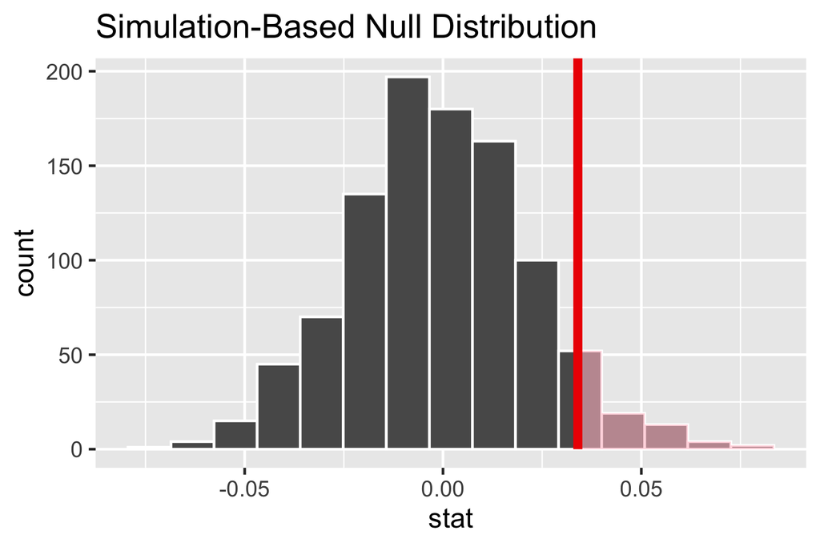

```r
visualize(null_distribution) +
  shade_p_value(obs_stat = obs_diff_prop, direction = "right")
```

shade everything at least this extreme

## What a p-value is

Reading The p-value

- It is the chance of data this extreme **if the null were true**.
- It is **not** the probability the null is true.
- A small p-value is evidence **against** the null, not proof of the alternative.
- A large p-value is not evidence that nothing is going on.
- Significance is not importance: report the **size** of the effect too.